# Prosper Loan Data Investigation

## by Angel Newportright

## Investigation Overview

For this presentation, I focused on four key Insights;

1. The top 10 Listing Category by loan count and percentage. This is to examine the most common reasons for which borrowers use the Prosper platform
2. The employment category has the higest number of completed, defaulted and chargedoff loans. This is to reveal the employment category that completed more of their loan payment.
3. The relationship that exist betweeen the number of friends that invested in a loan and number of investors that are not friends. This is to examine the correlation significance a numerical variable has on another numerical veriable.
4. Income Status Impact on Loan Repayment Completion.

## Dataset Overview

This dataset contains observations from the Prosper platform. [**Prosper**](https://www.prosper.com/) is a **peer-to-peer lending platform** that provides personal loans to borrowers with fair or good credit. This data set contains 113,937 loans with 81 variables on each loan, including loan amount, borrower rate (or interest rate), current loan status, borrower income, and many others. Howerer, because we were not expected to explore all of the variables in the dataset we focused our investigation on 20 variables. Included is the data [**dictionary**](https://docs.google.com/spreadsheets/d/1gDyi_L4UvIrLTEC6Wri5nbaMmkGmLQBk-Yx3z0XDEtI/edit#gid=0). that explains the variables in the data set. Please see data dictionary for more information

## Top 10 Listing Category by Loan Count and Percentage

The first insight we want to obtain from our investigation is to know the top 10 reason why borrowers solicit for loan via the `Prosper platform`.

From our investigation we oberserved that

1. Most loans were taken for debt consolidation.

   > What is Debt consolidation: This refers to the act of taking out a new loan to pay off other smaller liabilities and consumer debts
2. The Listing Category with the second hightest count of loan is `Not Available` category. What this means is that; a large number of applicants couldn't find the category which defines thier purpose of application.

   > To tackle this: The `Prosper`platform can provide option for new applicants to enter the reason for thier loan.

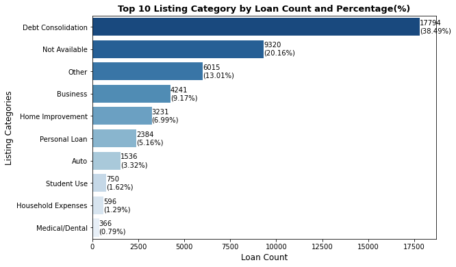

## Average Loan Amount and Status Across Employment Categories

The second insight we want to obtain from our investigation is to know which employment category has the higest number of completed, defaulted and chargedoff loans as well as the average loan amount across the categories.

From the pointplot below we can see that

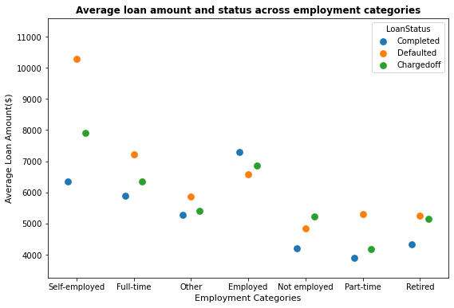

## Correlation Matrix of Prosper Loan Data

The third insight we want to obtain from our investigation is to know the degree of correlation that exist amongst the numerical variables of our dataset.

We discovered that

   > From our visual below we can say that the larger a loan amount is, the higher the number of investors who would invest in the loan. However, the stated monthly income of an applicant has a degree of impresion on investors.
2. There is a strong corralation between the number of friends who invest in a loan and the number of recomendations a the borrower has.

   > This simply means that friends who invest in a loan are most likely to make a recomendation.

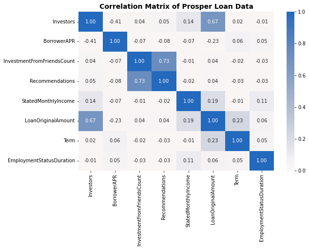

## Income Status Impact on Loan Repayment Completion

The last insight we want obtain form our investigation is to know the which category of borrowers obtained more loans and which completed more of their loan payment.

From our plot we can see that

1. Borrowers with verifiable income has more counts in terms of **total number of loan obtained** and **clompleted** loan repayments.

   > This means that investors were more willing to invest in loans whose borrower's income were verifiable and this category of borrowers completed more of their loan payments.
2. Borrowers with Income Not-Verifiable has relavely larger number of **charged off** loans.

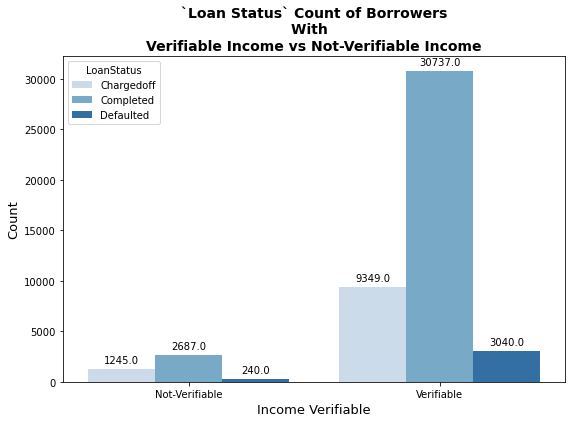